# Inflation forecasting with a RNN

The code is based in Machine Learning Mastery's code, available [here](https://mc.ai/how-to-develop-lstm-models-for-time-series-forecasting/). I'm switching from R to Python due to the lack of available literature on multi-step time series forecasting. Most available manuals for R teach how to train a neural network using the 'keras' package and only a few deal with actual forecasting. However, there is no multi-step forecast or the code is no self-explanatory. On the other hand, Python examples and manuals are abundant and code is cleaner than R's version.

## Disclaimer

Since the 'Neural Network for the US' section was used for experimenting, it is harder to read. A far more organized code is available later on the 'Neural Network for the EA' section. For understanding the code is highly recommended to study that section.

## Data

The first thing is to load the packages that we will be using:

```python
import pandas as pd #data manipulation
import numpy as np #data manipulation
from numpy import array
from numpy import hstack
from numpy.random import seed
seed(123)
import tensorflow as tf
import datetime
from datetime import datetime, timedelta
from sklearn import preprocessing #preprocessing
import math as math

import keras as keras #keras package for neural networks
from keras.models import Sequential
from keras.layers import Dense #dense layers
from keras.layers import LSTM #LSTM layers
from keras.layers import Dropout #Dropout
from keras.layers import *
from keras.callbacks import EarlyStopping
import pydot as pyd
from IPython.display import SVG
from keras.utils.vis_utils import plot_model #plot network's structure
import matplotlib.pyplot as plt #plots
import time
from collections import Counter
import os
os.chdir('..')
import csv #save output
import math
```

Now we load the data, Remember that we transformed each country's dataframe into a csv file to make this process easier.

```python
dataUS = pd.read_csv(r'C:\Users\aasg\OneDrive\Escritorio\Tilburg University\Thesis\R_Files\dfUS.csv', sep = ',', index_col = 1)
dataUS = dataUS.drop('Unnamed: 0', 1) #drops first column - it contains no informtion
dataEA = pd.read_csv(r'C:\Users\aasg\OneDrive\Escritorio\Tilburg University\Thesis\R_Files\dfEA.csv', sep = ',', index_col = 1)
dataEA = dataEA.drop('Unnamed: 0', 1) #drops first column - it contains no informtion
dataNL = pd.read_csv(r'C:\Users\aasg\OneDrive\Escritorio\Tilburg University\Thesis\R_Files\dfNL.csv', sep = ',', index_col = 1)
dataNL = dataNL.drop('Unnamed: 0', 1) #drops first column - it contains no informtion
dataCL = pd.read_csv(r'C:\Users\aasg\OneDrive\Escritorio\Tilburg University\Thesis\R_Files\dfCL.csv', sep = ',', index_col = 1)
dataCL = dataCL.drop('Unnamed: 0', 1) #drops first column - it contains no informtion
dataMX = pd.read_csv(r'C:\Users\aasg\OneDrive\Escritorio\Tilburg University\Thesis\R_Files\dfMX.csv', sep = ',', index_col = 1)
dataMX = dataMX.drop('Unnamed: 0', 1) #drops first column - it contains no informtion
```

```python
dataUS.head()
```

| mdate | infUS | intrateUS | M2US | OutputGapUS | urateUS | RERUS | realWUS |
| --- | --- | --- | --- | --- | --- | --- | --- |
| 1995-01-01 | 0.029126 | 0.0553 | -0.004152 | 0.016030 | 0.056 | -0.006750 | -0.004126 |
| 1995-02-01 | 0.029716 | 0.0592 | -0.005056 | 0.009197 | 0.054 | -0.010416 | -0.004827 |
| 1995-03-01 | 0.029620 | 0.0598 | -0.004879 | 0.005815 | 0.054 | -0.025575 | -0.002953 |
| 1995-04-01 | 0.031511 | 0.0605 | -0.002951 | 0.000972 | 0.058 | -0.063330 | -0.005779 |
| 1995-05-01 | 0.030789 | 0.0601 | 0.002985 | 0.000249 | 0.056 | -0.060218 | -0.004217 |

```python
dataEA.head()
```

| mdateEA | infEA | intrateEA | M2EA | OutputGapEA | urateEA | REREA |
| --- | --- | --- | --- | --- | --- | --- |
| 1999-01-01 | 0.007343 | 0.045 | -0.024007 | 0.000651 | 0.1007 | 0.058503 |
| 1999-02-01 | 0.007067 | 0.045 | -0.011594 | -0.019115 | 0.0999 | 0.055158 |
| 1999-03-01 | 0.008832 | 0.045 | -0.012022 | -0.007233 | 0.0993 | 0.051843 |
| 1999-04-01 | 0.010715 | 0.035 | -0.011421 | -0.008026 | 0.0992 | 0.036472 |
| 1999-05-01 | 0.009210 | 0.035 | -0.009605 | -0.006792 | 0.0987 | 0.000442 |

```python
dataNL.head()
```

| mdateNL | infNL | intrateNL | M2NL | OutputGapNL | urateNL | RERNL | realWNL |
| --- | --- | --- | --- | --- | --- | --- | --- |
| 1999-01-01 | 0.018 | 0.045 | -0.024007 | 0.004446 | 0.0456 | 0.058503 | 0.011223 |
| 1999-02-01 | 0.017 | 0.045 | -0.011594 | 0.008765 | 0.0450 | 0.055158 | 0.010478 |
| 1999-03-01 | 0.018 | 0.045 | -0.012022 | 0.016176 | 0.0444 | 0.051843 | 0.011096 |
| 1999-04-01 | 0.017 | 0.035 | -0.011421 | -0.002686 | 0.0438 | 0.036472 | 0.012472 |
| 1999-05-01 | 0.020 | 0.035 | -0.009605 | -0.004268 | 0.0432 | 0.000442 | 0.008668 |

```python
dataCL.head()
```

| mdateCL | infCL | intrateCL | M2CL | OutputGapCL | urateCL | RERCL | realWCL |
| --- | --- | --- | --- | --- | --- | --- | --- |
| 1996-01-01 | 0.078108 | 0.0670 | 0.023144 | 0.060058 | 0.069563 | -0.054705 | 0.054510 |
| 1996-02-01 | 0.078242 | 0.0670 | 0.022891 | 0.057940 | 0.065751 | -0.071141 | 0.051957 |
| 1996-03-01 | 0.079482 | 0.0670 | 0.011856 | 0.046862 | 0.060844 | -0.082723 | 0.042118 |
| 1996-04-01 | 0.083828 | 0.0731 | 0.014575 | 0.044179 | 0.062606 | -0.076444 | 0.036468 |
| 1996-05-01 | 0.085958 | 0.0750 | 0.008233 | 0.034651 | 0.065797 | -0.038312 | 0.037044 |

```python
dataMX.head()
```

| mdateMX | infMX | intrateMX | M2MX | OutputGapMX | urateMX | RERMX | realWMX |
| --- | --- | --- | --- | --- | --- | --- | --- |
| 2001-01-01 | 0.081117 | 0.1862 | 2.269282e-07 | -0.019281 | 0.0220 | -0.034611 | 0.055906 |
| 2001-02-01 | 0.070902 | 0.1812 | 5.399502e-03 | -0.024610 | 0.0278 | -0.028598 | 0.058606 |
| 2001-03-01 | 0.071745 | 0.1728 | 6.803788e-03 | -0.026700 | 0.0237 | -0.030444 | 0.058781 |
| 2001-04-01 | 0.071058 | 0.1636 | 6.651294e-03 | -0.045877 | 0.0241 | -0.064321 | 0.061703 |
| 2001-05-01 | 0.069517 | 0.1409 | 4.889920e-03 | -0.029931 | 0.0248 | -0.088403 | 0.046045 |

Due to its nature, all data is conveniently in the (-1) - 1 range, facilitating data preprocessing.

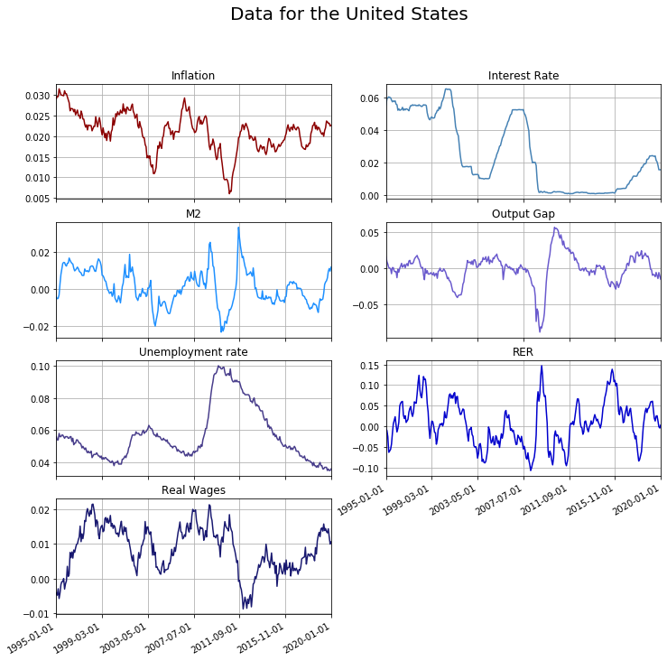

```python
dataUS.plot(kind ='line',
            subplots = True,
            grid = True,
            figsize = (12,12),
            title = ['Inflation', 'Interest Rate', 'M2', 'Output Gap', 'Unemployment rate', 'RER', 'Real Wages'],
            layout = (4,2),
            sharex = True,
            sharey = False,
            legend = False,
            style = ['darkred', 'steelblue', 'dodgerblue', 'slateblue', 'darkslateblue', 'mediumblue', 'midnightblue'])

[ax.set_xlabel('') for ax in plt.gcf().axes]
plt.suptitle('Data for the United States', fontsize = 20)
plt.show()
plt.savefig(r'C:\Users\aasg\OneDrive\Escritorio\Tilburg University\Thesis\Python_Files\Pic_data\data_us.png')
```

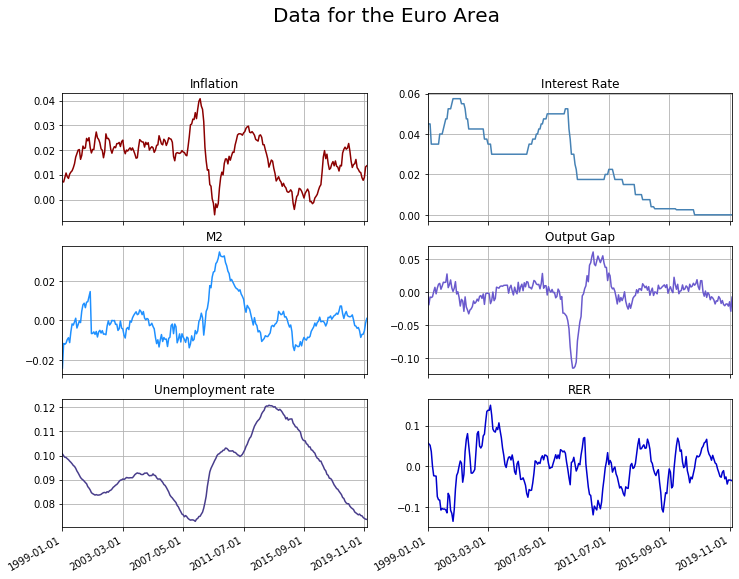

```python
dataEA.plot(kind ='line',
            subplots = True,
            grid = True,
            figsize = (12,12),
            title = ['Inflation', 'Interest Rate', 'M2', 'Output Gap', 'Unemployment rate', 'RER'],
            layout = (4,2),
            sharex = True,
            sharey = False,
            legend = False,
            style = ['darkred', 'steelblue', 'dodgerblue', 'slateblue', 'darkslateblue', 'mediumblue'])

[ax.set_xlabel('') for ax in plt.gcf().axes]
plt.suptitle('Data for the Euro Area', fontsize = 20)
plt.show()
plt.savefig(r'C:\Users\aasg\OneDrive\Escritorio\Tilburg University\Thesis\Python_Files\Pic_data\data_ea.png')
```

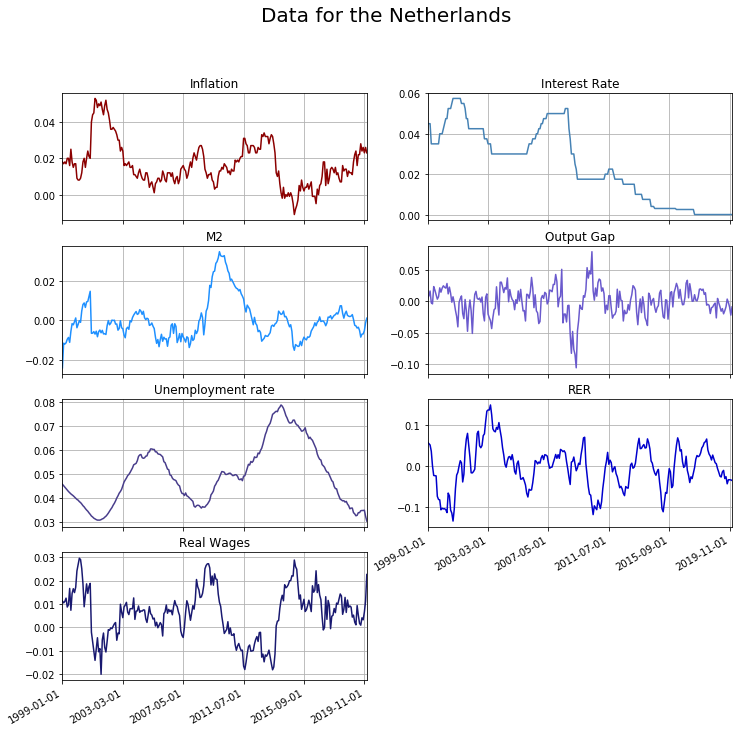

```python
dataNL.plot(kind ='line',
            subplots = True,
            grid = True,
            figsize = (12,12),
            title = ['Inflation', 'Interest Rate', 'M2', 'Output Gap', 'Unemployment rate', 'RER', 'Real Wages'],
            layout = (4,2),
            sharex = True,
            sharey = False,
            legend = False,
            style = ['darkred', 'steelblue', 'dodgerblue', 'slateblue', 'darkslateblue', 'mediumblue', 'midnightblue'])

[ax.set_xlabel('') for ax in plt.gcf().axes]
plt.suptitle('Data for the Netherlands', fontsize = 20)
plt.show()
plt.savefig(r'C:\Users\aasg\OneDrive\Escritorio\Tilburg University\Thesis\Python_Files\Pic_data\data_nl.png')
```

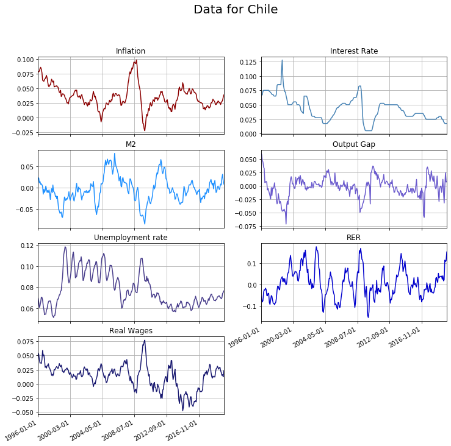

```python
dataCL.plot(kind ='line',
            subplots = True,
            grid = True,
            figsize = (12,12),
            title = ['Inflation', 'Interest Rate', 'M2', 'Output Gap', 'Unemployment rate', 'RER', 'Real Wages'],
            layout = (4,2),
            sharex = True,
            sharey = False,
            legend = False,
            style = ['darkred', 'steelblue', 'dodgerblue', 'slateblue', 'darkslateblue', 'mediumblue', 'midnightblue'])

[ax.set_xlabel('') for ax in plt.gcf().axes]
plt.suptitle('Data for Chile', fontsize = 20)
plt.show()
plt.savefig(r'C:\Users\aasg\OneDrive\Escritorio\Tilburg University\Thesis\Python_Files\Pic_data\data_cl.png')
```

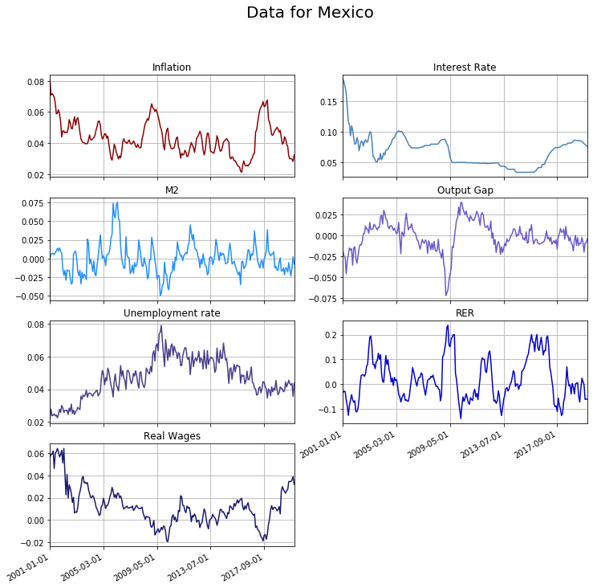

```python
dataMX.plot(kind ='line',
            subplots = True,
            grid = True,
            figsize = (12,12),
            title = ['Inflation', 'Interest Rate', 'M2', 'Output Gap', 'Unemployment rate', 'RER', 'Real Wages'],
            layout = (4,2),
            sharex = True,
            sharey = False,
            legend = False,
            style = ['darkred', 'steelblue', 'dodgerblue', 'slateblue', 'darkslateblue', 'mediumblue', 'midnightblue'])

[ax.set_xlabel('') for ax in plt.gcf().axes]
plt.suptitle('Data for Mexico', fontsize = 20)
plt.show()
plt.savefig(r'C:\Users\aasg\OneDrive\Escritorio\Tilburg University\Thesis\Python_Files\Pic_data\data_mx.png')
```

Lets start our neural network forecast with the US.